# Métodos con remuestreo

Ejemplo de solución ejercicio prático N°8

Como vimos, la Encuesta de Caracterización Socioeconómica Nacional (Casen) es realizada por el Ministerio de Desarrollo Social de forma periódica para conocer la situación de los hogares chilenos con relación a aspectos demográficos, de educación, salud, vivienda, trabajo e ingresos. Es la principal fuente de información para estimar la magnitud de la pobreza y la distribución del ingreso en el país.

## Pregunta 1

Propongan una pregunta de investigación original, que involucre la comparación de una frecuencia de un evento o característica en dos grupos independientes. Fijando una semilla propia, seleccionen una muestra aleatoria de hogares (100 < $n$ < 150) y respondan la pregunta propuesta utilizando el método **Monte Carlo**.

Pensando en la nueva política estatal sobre pensiones y el apoyo a personas con discapacidad, consideraremos la siguiente pregunta: *la proporción de entrevistados fuera de la Región Metropolitana que presentan problemas significativos de movilidad pero que están cotizando para su jubilación tiene igual proporción entre hombres y mujeres*.

Esta pregunta plantea la comparación de dos proporciones. Luego, el estadístico de interés que debemos utilizar en este caso es la **diferencia de las proporciones** entre dos grupos independiente de personas.

Comencemos cargando los paquetes que vamos a utilizar.

```r
library(dplyr)
library(ggpubr)
library(purrr)
library(rsample)
library(tidyr)
```

Primero, carguemos los datos.

```r
src_dir <- "~/../Downloads"
src_dir <- "~/Downloads"
src_basename <- "EP08 Datos CASEN 2017.csv"
src_file <- file.path(src_dir, src_basename)
datos <- read.csv(file = src_file, stringsAsFactors = TRUE)
```

Filtremos para obtener los datos de interés y obtengamos la muestra que se solicita.

```r
set.seed(347)
n1 <- 150
muestra1 <- datos |>
  filter(region != "Región Metropolitana de Santiago") |>
  filter(h10e %in% c("No puede hacerlo", "Sí, mucha dificultad")) |>
  filter(!is.na(o29)) |> mutate(cotiza = if_else(o29 == "No está cotizando", "No", "Sí")) |>
  mutate(cotiza = factor(cotiza)) |>
  select(sexo, cotiza) |>
  sample_n(n1)
```

Formulemos las hipótesis:

H<sub>0</sub>: las proporciones de hombres ($p_h$) y mujeres ($p_m$) que no viven en la Región Metropolitana y que declaran tener problemas serios de movilidad pero que están cotizando para su jubilación son iguales: $p_h - p_m = 0$.

H<sub>A</sub>: Por el contrario, estas proporciones son distintas: $p_h - p_m \ne 0$.

Generemos las remuestras que vamos a utilizar, incluyendo la muestra original. El enunciado nos indica que usemos **permutaciones** (método Monte Carlo). Como de costumbre, tenemos cuidado de fijar una semilla que nos permita obtener los mismos resultados cada que vez que ejecutemos el script.

```r
# Crear las remuestras, incluyendo la muestra original
R = 5999
set.seed(349)
remuestras <- permutations(muestra1, permute = sexo, times = R, apparent = TRUE)
```

Notemos que solo hemos permutado la variable `sexo`, que es la que define en qué grupo está incluido cada caso.

Definamos una función que calcule la diferencia entre las proporciones de hombres y mujeres que cotizan para su jubilación para una remuestra.

```r
prop_dif <- function(remuestra, ...) {
  analysis(remuestra) |>
    group_by(sexo) |>
    summarise(prop = mean(cotiza == "Sí")) |>
    summarise(term = "Dif. prop.", estimate = prop[1] - prop[2]) |>
    pull()
}
```

Corresponde obtener la distribución permutada de la diferencia de las proporciones entre hombres y mujeres. Notemos que desanidamos los valores del estadístico de interés para que queden directamente como columnas de la matriz de datos.

```r
dist_perm <- remuestras |>
  mutate(dif_prop = map(splits, prop_dif)) |>
  unnest(dif_prop)
```

Averigüemos cuál es la diferencia observada en la muestra original.

```r
dif_obs <- dist_perm |>
  filter(id == "Apparent") |>
  pull(dif_prop)
```

Revisemos cómo se ve la distribución permutada respecto de la diferencia observada.

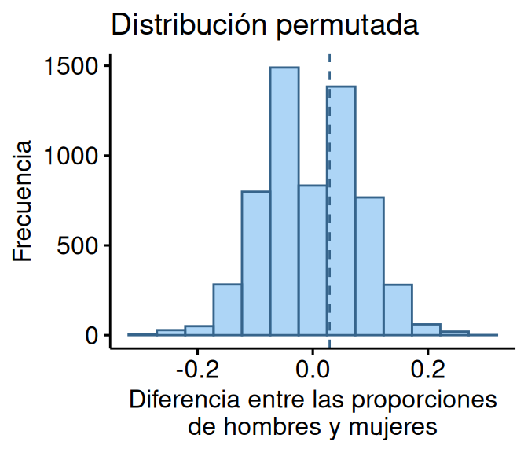

```r
p1 <- gghistogram(dist_perm, x = "dif_prop", bins = 13,
                  color = "steelblue4", fill = "steelblue2",
                  title = "Distribución permutada",
                  xlab = "Diferencia entre las proporciones\nde hombres y mujeres",
                  ylab = "Frecuencia")
p1 <- p1 + geom_vline(xintercept = dif_obs, color="steelblue4", linetype = "dashed")
plot(p1)
```

Podemos ver que la diferencia de las proporciones observada en la muestra original se ubica cerca del centro de distribución permutada, no muy lejos del valor cero.

Calculemos el intervalo de 95% confianza y el valor p para una prueba bilateral (usando el valor absoluto de las diferencias) con 95% de confianza, es decir la probabilidad de encontrar diferencias al menos tan extremas como la diferencia observada.

```r
alfa <- 0.05
ic1 <- quantile(dist_perm[["dif_prop"]], c(alfa / 2, 1 - alfa / 2))
msg <- "Intervalos de 95% confianza para la diferencia de dos proporciones"
cat(msg, ":\n", sep = "")
cat(rep("-", nchar(msg)), "\n", sep = "")
print(round(ic1, 3))

# Calcular el valor p
n_extremos1 <- dist_perm |>
  filter(abs(dif_prop) >= abs(dif_obs)) |>
  summarise(n = n())
valor_p1 <- n_extremos1 |>
  pull(n) / (R + 1)   # n_extremos ya incluye la diferencia observada
cat(sprintf("\nP-valor: %.3f\n", valor_p1))
```

```
Intervalos de 95% confianza para la diferencia de dos proporciones:
------------------------------------------------------------------
  2.5%  97.5%
-0.168  0.170

P-valor: 0.725
```

Lo que nos lleva a la siguiente conclusión:

Se puede concluir, con 95% confianza, que no hay evidencia suficiente para rechazar la hipótesis nula ($\small p = 0{,}725$) y tenemos que concluir que no es posible descartar que las proporciones de hombres y mujeres con problemas serios de movilidad que están cotizando para su jubilación son iguales (IC $\small 95\%=[-0{,}168; 0{,}170]$).

## Pregunta 2

Propongan una pregunta de investigación original, que involucre la comparación de las medias de más de dos grupos independientes. Fijando una semilla distinta a la anterior, seleccionen una muestra aleatoria de hogares (200 < $n$ < 300) y respondan la pregunta propuesta utilizando **bootstrapping**. Solo por ejercicio académico, aplique un análisis **post-hoc con bootstrapping** aunque este no sea necesario.

En este caso, consideraremos la pregunta: *¿es igual el ingreso per cápita en las regiones de Atacama, Coquimbo y del Maule?*

Esta pregunta requiere contrastar las medias de 3 grupos independientes. Al haber más de dos medias, no es posible comparar directamente sus diferencias. Así, lo más conveniente en este caso es utilizar el **estadístico F** para evaluar su igualdad.

Filtremos los datos y obtengamos la muestra como se solicita.

```r
n2 <- 275
set.seed(572)
regiones <- c("Región de Coquimbo", "Región de Atacama", "Región del Maule")
muestra2 <- datos |>
  filter(region %in% regiones) |>
  droplevels() |>
  mutate(region = recode(region, "Región de Atacama" = "Atacama")) |>
  mutate(region = recode(region, "Región de Coquimbo" = "Coquimbo")) |>
  mutate(region = recode(region, "Región del Maule" = "Maule")) |>
  select(ytotcorh, numper, region) |>
  mutate(ypercap = ytotcorh / numper / 1000, .keep = "unused") |>
  sample_n(n2)
```

Cabe señalar que, para mayor comodidad, hemos calculado el ingreso per cápita en miles de pesos (en vez de en pesos).

Formulamos las hipótesis:

H<sub>0</sub>: El ingreso per cápita promedio es igual en las regiones de Atacama ($\mu_{\small A}$), Coquimbo ($\mu_{\small C}$) y el Maule ($\mu_{\small M}$): $\mu_{\small A}=\mu_{\small C}=\mu_{\small M}$.

H<sub>A</sub>: El ingreso per cápita promedio es distinto para al menos una de las regiones comparadas: $\exists (a,b) \in \{A, C, M\} \mid \mu_{a}\ne\mu_{b}$.

Revisemos los datos.

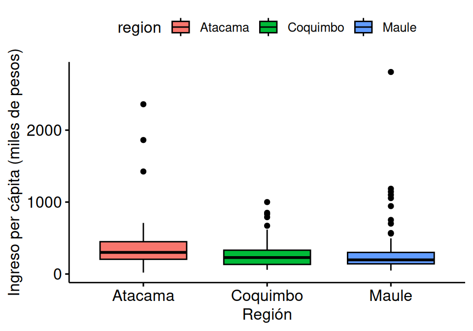

```r
p2 <- ggboxplot(muestra2, x = "region", y = "ypercap", fill = "region")
p2 <- p2 + xlab("Región") + ylab("Ingreso per cápita (miles de pesos)")
plot(p2)
```

En la figura, podemos ver que las muestras de datos exhiben cierta asimetría, no parecen cumplir con la condición de homocedasticidad (cajas de altura diferente) y presentan numerosos valores atípicos. Así, no podemos usar un método de análisis clásico y debemos recurrir a métodos apropiados, en este caso **remuestreo con bootstrapping**.

Revisemos el tamaño de las muestras y las varianzas de las observaciones en cada grupo.

```r
muestra2 |> group_by(region) |>
  summarise(n = n(), varianza = var(ypercap))
```

```
# A tibble: 3 × 3
  region       n varianza
  <fct>    <int>    <dbl>
1 Atacama     58  155244.
2 Coquimbo    74   39636.
3 Maule      143   86650.
```

Estamos en serios problemas. Recordemos que ANOVA, que usa el estadístico F de Fisher, es robusta a desviaciones **moderadas** de normalidad **u** homocedasticidad cuando las muestras tienen **igual tamaño**. Pero estas desviaciones se **amplifican** cuando las muestras tienen tamaños distintos, por que una distribución bootstrap de estadísticos F obtenidos de remuestras desbalanceadas y heterocedásticas son poco confiables pues podrían estar sesgados.

En clases vimos que para reflejar la hipótesis nula cuando teníamos dos muestras podíamos **recentrar** la distribución bootstrap en el valor nulo o **desplazar** las muestras para que la diferencias de sus medias fuera el valor nulo **antes del remuestreo**. Para el estadístico F, tiene más sentido la segunda alternativa.

Sin embargo, esto no sería suficiente en este caso: aunque las muestras independientes tuvieran las mismas medias, el problema de desbalance y heterocedasticidad se mantiene.

Entonces, considerando que si la hipótesis nula se cumple las tres muestras tienen la misma media y la misma varianza, debemos hacer estos ajustes en los datos antes del remuestreo, siguiendo las ideas propuestas por Fisher & Hall (1990), Hall & Wilson (1991) y Martin (2007).

Primero vamos a obtener las medidas generales (*pooled*).

```r
gral <- muestra2 |>
  summarise(media = mean(ypercap), desv_est = sd(ypercap))
```

Ahora **desplazamos** los valores vistos para que los tres grupos tengan la misma media e igual varianza (en rigor, desviación estándar).

```r
muestra2_h0 <- muestra2 |>
  group_by(region) |>
  mutate(ypercap = ypercap - mean(ypercap)) |>
  mutate(ypercap = ypercap * (gral[["desv_est"]] / sd(ypercap))) |>
  mutate(ypercap = ypercap + gral[["media"]]) |>
  ungroup()
```

Verifiquemos que se cumple la hipótesis nula.

```r
muestra2_h0 |> group_by(region) |>
  summarise(n = n(), media = mean(ypercap), varianza = var(ypercap))
```

```
# A tibble: 3 × 4
  region       n media varianza
  <fct>    <int> <dbl>    <dbl>
1 Atacama     58  301.   90702.
2 Coquimbo    74  301.   90702.
3 Maule      143  301.   90702.
```

Revisemos cómo lucen ahora los datos.

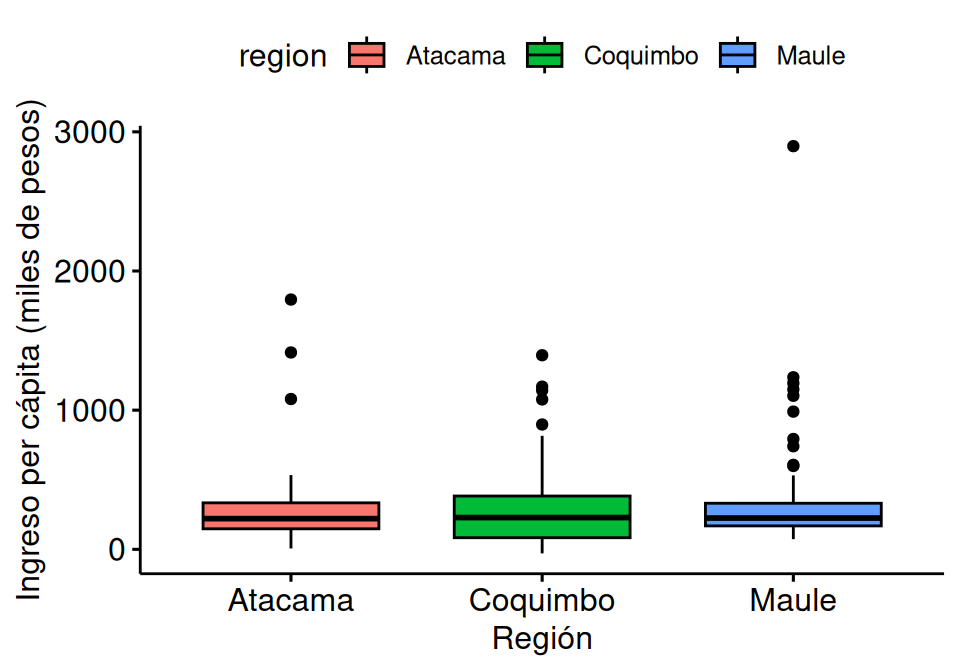

```r
p3 <- ggboxplot(muestra2_h0, x = "region", y = "ypercap", fill = "region")
p3 <- p3 + xlab("Región") + ylab("Ingreso per cápita (miles de pesos)")
plot(p3)
```

Podemos verificar que la forma de las muestras se ha mantenido relativamente bien, a pesar de que ahora tienen la misma media e igual varianza (aunque se nota el aumento en dispersión introducida en los datos de la región de Coquimbo).

Corresponde definir las remuestras para el análisis con bootstrapping. Puesto que las muestras están desbalanceadas, debemos **mantener esos tamaños** en el remuestreo, indicando a la función `bootstraps()` que el factor `region` define estratos en los datos.

```r
B <- 2999
set.seed(573)
remuestras_h0 <- bootstraps(muestra2_h0, times = B, strata = region)
```

Definimos una función que calcule el estadístico de interés, que como se dijo corresponde al estadístico F usado por ANOVA para muestras independientes, para una remuestra.

```r
library(rstatix)

calc_F <- function(remuestra, ...) {
  analysis(remuestra) |>
  mutate(id = row_number()) |>
  anova_test(dv = ypercap, wid = id, between = region, type = 1) |>
  summarise(term = "F", estimate = F)
}
```

Ahora podemos obtener la distribución bootstrap del estadístico F para las muestras que cumplen con la hipótesis nula, desanidando los valores del estadístico estimados para cada remuestra.

```r
F_bt_h0 <- remuestras_h0 |>
  mutate(stats = map(splits, calc_F)) |>
  unnest(stats)
```

Revisemos cómo se ve la distribución bootstrap que cumple con la hipótesis nula.

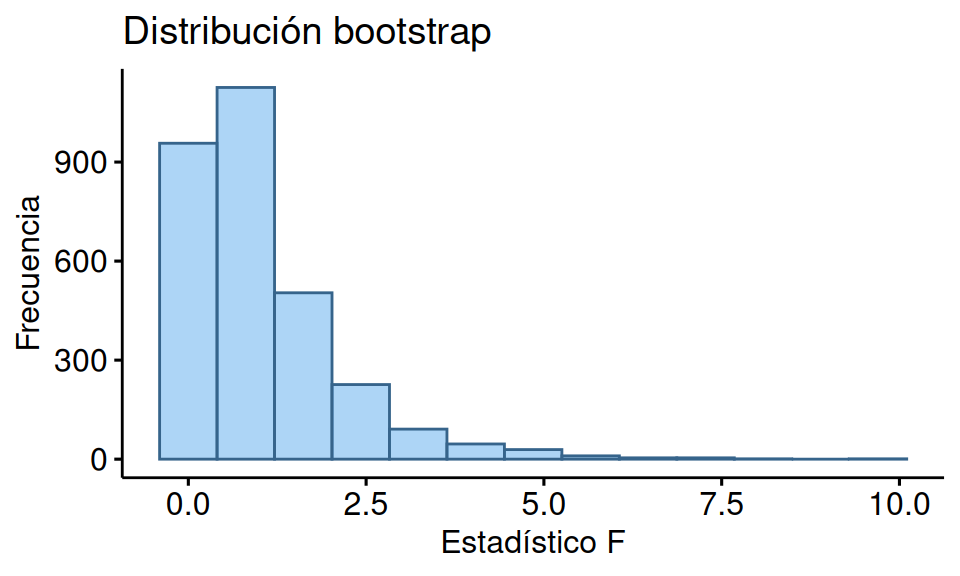

```r
p4 <- gghistogram(F_bt_h0, x = "estimate", bins = 13,
                  color = "steelblue4", fill = "steelblue2",
                  title = "Distribución bootstrap",
                  xlab = "Estadístico F",
                  ylab = "Frecuencia")
plot(p4)
```

Averigüemos cuál es la diferencia observada en la muestra original.

```r
aov_obs <- muestra2 |>
  mutate(id = row_number()) |>
  anova_test(dv = ypercap, wid = id, between = region, type = 1)
F_obs <- aov_obs |> pull(F)
```

Miremos el resultado:

```r
print(aov_obs)
```

```
ANOVA Table (type I tests)

  Effect DFn DFd     F     p p<.05   ges
1 region   2 272 4.557 0.011     * 0.032
```

Y veamos cómo se compara con la distribución bootstrap obtenida.

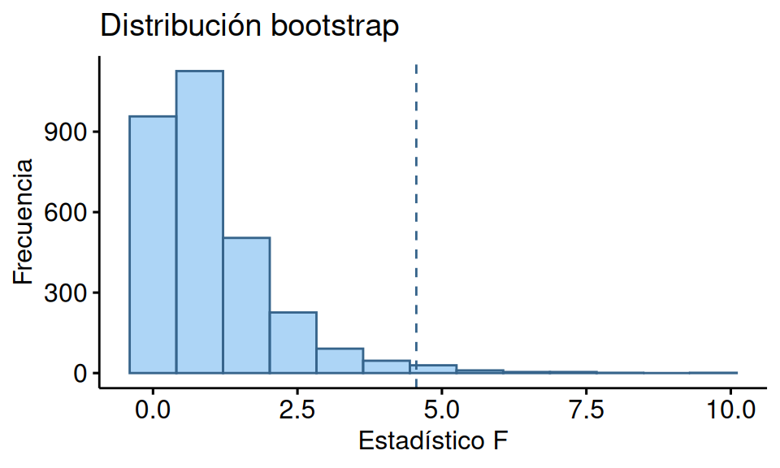

```r
p4a <- p4 + geom_vline(xintercept = F_obs, color="steelblue4", linetype = "dashed")
plot(p4a)
```

Siguiendo lo aprendido, podemos obtener un valor p basado en la distribución bootstrap del estadístico.

```r
n_extremos <- F_bt_h0 |>
  filter(estimate >= F_obs) |>
  summarise(n = n())
p_valor <- (n_extremos + 1) / (B + 1)

cat(sprintf("Valor p*: %.3f\n", p_valor))
```

```
Valor p*: 0.015
```

Podemos ver que el valor p* no es muy diferente del valor p del método asintótico. Sin embargo, si no quisimos usar las estimaciones del estadístico F a partir de remuestras de las muestras originales porque podían estar sesgadas, ¿por qué usamos la estimación F de las muestras originales en este cálculo? No parece congruente, ya que si la estimación está sesgada, el valor p* podría también estar sesgado.

Afortunadamente se tiene una solución: usar el denominado procedimiento ANOVA de una vía de Welch, que verifica la igualdad ómnibus de las medias de grupos independientes definidos por un factor **sin asumir igualdad de las varianzas**. El paquete `rstatix` provee la función `welch_anova_test(data, formula)`, que es un *wrapper* de la función base `oneway.test()`, que implementa esta alternativa de manera *tidy*. Usemos entonces esta función para obtener el valor observado del estadístico de interés.

```r
aov_welch_obs <- muestra2 |>
  welch_anova_test(ypercap ~ region)
F_welch_obs <- aov_welch_obs |> pull(statistic)
```

Miremos el nuevo resultado:

```r
print(as.data.frame(aov_welch_obs), digits = 5, nsmall = 2)
```

```
      .y.   n statistic DFn    DFd     p      method
1 ypercap 275      2.92   2 130.86 0.058 Welch ANOVA
```

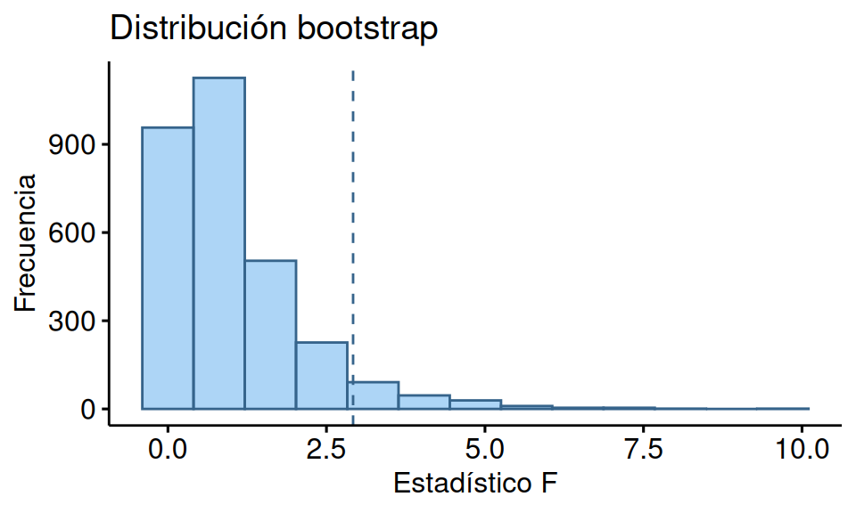

```r
p4b <- p4 + geom_vline(xintercept = F_welch_obs, color="steelblue4", linetype = "dashed")
plot(p4b)
```

Y recalculemos el valor p basado en la distribución bootstrap del estadístico bajo la hipótesis nula.

```r
n_extremos_welch <- F_bt_h0 |>
  filter(estimate >= F_welch_obs) |>
  summarise(n = n())
p_valor_welch <- (n_extremos_welch + 1) / (B + 1)

cat(sprintf("Valor p*: %.3f\n", p_valor_welch))
```

```
Valor p*: 0.058
```

Primero, podemos notar que el valor p* **coincide** con el valor p asintótico: $\small F(2; 130{,}86) = 2{,}92$; $\small p^{*} = p = 0{,}058$. Y en segundo lugar, debemos notar que al utilizar el estadístico F de Welch, como alternativa al tradicional F de Fisher, la prueba ómnibus ya **no resulta significativa** al nivel $\small \alpha = 0{,}05$. De este modo, debemos hacer la siguiente conclusión:

El análisis bootstrap realizado indica, con 95% confianza, que no existen diferencias significativas en el ingreso per cápita promedio entre las regiones de Atacama, Coquimbo y el Maule.

Una alternativa a realizar el desplazamiento de los valores en las muestras originales, para que estas tengan la misma media e igual varianza antes de aplicar bootstrapping, sería realizar las remuestras de la manera tradicional (aunque igualmente estratificada) pero que la función `calc_F()` devolviera el estadístico F de Welch para cada remuestra usando la función `welch_anova_test()`, en vez del tradicional F de Fisher conseguido con la función `anova_test()`, como la alternativa seguida en este ejemplo. Esto además permitiría obtener un intervalo de confianza para el estadístico F (de Welch), cosa que no pudimos hacer aquí.

Queda como ejercicio propuesto realizar este procedimiento con esta de idea alternativa.

Luego, en rigor, no correspondería hacer un análisis post-hoc de estos datos. Sin embargo, como se solicita en el enunciado, por ejercicio académico, aplicaremos un **análisis post-hoc con bootstrapping**.

Recordando que el procedimiento HSD de Tukey es muy sensible a violaciones en las condiciones para aplicar el procedimiento ANOVA para muestras independientes, haremos uso del **procedimiento post-hoc de Games-Howell**, que combina la lógica del rango estudentizado de Tukey con la corrección de grados de libertad de Welch, diseñado para situaciones donde se viola el supuesto homocedasticidad y los tamaños de las muestras son desiguales (Games & Howell, 1976).

Esta prueba de comparaciones múltiples post-hoc está disponible en la función `games_howell_test(data, formula, conf.level = 0.95)` del paquete `rstatix`.

```r
alfa <- 0.05

posthoc_obs <- muestra2 |>
  games_howell_test(ypercap ~ region, conf.level = 1 - alfa) |>
  select(-.y.)
print(as.data.frame(posthoc_obs), digits = 4, nsmall = 2)
```

```
    group1   group2 estimate conf.low conf.high p.adj p.adj.signif
1  Atacama Coquimbo -128.427  -263.79     6.935 0.067           ns
2  Atacama    Maule -134.652  -271.35     2.049 0.054           ns
3 Coquimbo    Maule   -6.225   -86.01    73.557 0.981           ns
```

Ahora definamos una función que obtenga la estimación de la diferencia de las medias entre pares de grupos, la que aparece con el nombre `estimate` en la matriz de datos que devuelve la función `games_howell_test()`.

```r
calc_dif_medias <- function(remuestra, ...) {
  analysis(remuestra) |>
  games_howell_test(ypercap ~ region, conf.level = 1 - alfa) |>
  reframe(term = paste(paste0("mean(", group2, ")"),
                       paste0("mean(", group1, ")"), sep = " - "),
          estimate = estimate)
}
```

Ya podemos obtener la distribución bootstrap de las diferencias de las medias entre pares de regiones, teniendo el cuidado de usar las mismas remuestras pero sobre los datos originales (y no en los datos desplazados).

```r
set.seed(573)
remuestras <- bootstraps(muestra2, times = B, strata = region)

dif_medias_bt <- remuestras |>
  mutate(stats = map(splits, calc_dif_medias))
```

Extraemos una tabla con las diferencias que usamos para construir histogramas de las distribuciones bootstrap de las diferencias de medias entre las regiones.

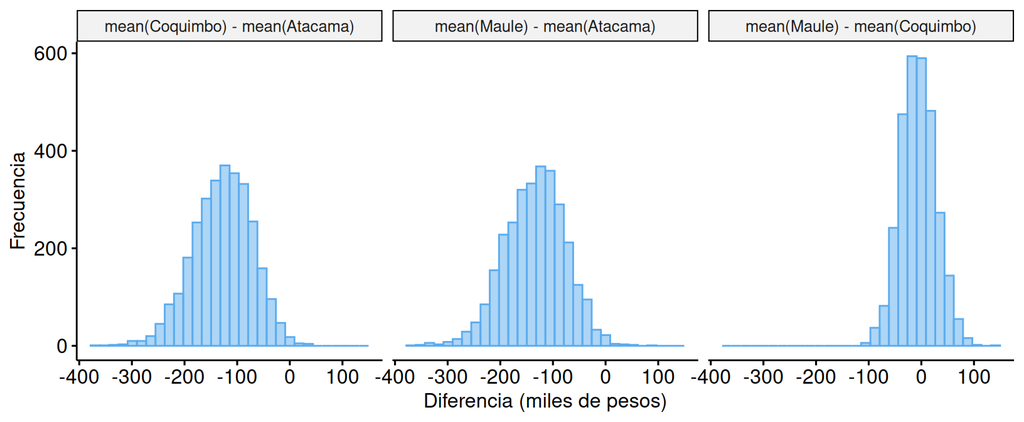

```r
dif_medias_bt_tbl <- dif_medias_bt |>
  select(stats) |>
  unnest(stats) |>
  mutate(term = factor(term))

p5 <- gghistogram(dif_medias_bt_tbl, x = "estimate", bins = 30,
                  color = "steelblue2", fill = "steelblue2",
                  xlab = "Diferencia (miles de pesos)", ylab = "Frecuencia",
                  legend = "none")
p5 <- p5 + facet_wrap(~ term)

plot(p5)
```

Con esta figura queda en claro que, si existiera una diferencia significativa en el ingreso per cápita, estas estarían entre la región de Atacama y las otras dos regiones. La región de Coquimbo y la del Maule muestran, en promedio, valores similares.

Obtengamos los intervalos de confianza que permitan confirmar esta intuición visual. Pero primero, para poder obtener intervalos de confianza con el método BCA, necesitamos agregar la muestra original a las remuestras.

```r
# Crear un objeto rset que incluya las muestras originales (apparent)
remuestras_aux <- bootstraps(muestra2, times = 1, strata = region, apparent = TRUE)

# Obtener el estadístico para este rset auxiliar
dif_medias_aux <- remuestras_aux |>
  mutate(stats = map(splits, calc_dif_medias))

# Extraer los resultados para las muestras originales
dif_medias_obs <- dif_medias_aux |>
  filter(id == "Apparent")

# Agregar estos resultados a la distribución bootstrap
dif_medias_bt_con_orig <- bind_rows(dif_medias_bt, dif_medias_obs)

# Restaurar clase y atributos que la función bind_rows() no copia,
# teniendo cuidado de añadir un nombre de fila extra y cambiar el
# atributo 'apparent'.
lista_atributos <- attributes(dif_medias_bt)
lista_atributos[["row.names"]] <- c(lista_atributos [["row.names"]],
                                    as.integer(lista_atributos[["times"]] + 1))
lista_atributos[["apparent"]] <- TRUE
attributes(dif_medias_bt_con_orig) <- lista_atributos
```

Ahora podemos proceder a estimar los intervalos de confianza usando las funciones provistas por el paquete `rsample`.

```r
ic_perc <- dif_medias_bt_con_orig |> int_pctl(statistics = stats, alpha = alfa)
ic_bias <- dif_medias_bt_con_orig |> int_bca(statistics = stats, alpha = alfa, .fn = calc_dif_medias)
ics <- bind_rows(ic_perc, ic_bias)

msg <- "Intervalos de confianza para la diferencia de dos medias entre regiones"
cat(msg, ":\n", sep = "")
cat(rep("-", nchar(msg)), "\n", sep = "")
print(as.data.frame(ics), digits = 4, nsmall = 2)
```

```
Intervalos de confianza para la diferencia de dos medias entre regiones:
-----------------------------------------------------------------------
                            term  .lower .estimate .upper .alpha    .method
1 mean(Coquimbo) - mean(Atacama) -242.87   -128.14 -26.63   0.05 percentile
2    mean(Maule) - mean(Atacama) -248.52   -134.17 -29.80   0.05 percentile
3   mean(Maule) - mean(Coquimbo)  -68.95     -6.03  61.35   0.05 percentile
4 mean(Coquimbo) - mean(Atacama) -266.39   -128.14 -40.39   0.05        BCa
5    mean(Maule) - mean(Atacama) -270.26   -134.17 -39.93   0.05        BCa
6   mean(Maule) - mean(Coquimbo)  -66.42     -6.03  65.66   0.05        BCa
```

Vemos que los intervalos presentan diferencias, probablemente por efecto de la leve asimetría que se observa en las distribuciones bootstrap, por lo que nos quedaremos con los intervalos calculados con el método BCA. En todo caso, ambos métodos llevan a la misma conclusión.

## Referencias

Fisher, N. I., & Hall, P. (1990). On bootstrap hypothesis testing. Australian Journal of Statistics, 32(2), 177-190.

Games, P. A., & Howell, J. F. (1976). Pairwise Multiple Comparison Procedures with Unequal N’s and/or Variances: A Monte Carlo Study. Journal of Educational and Behavioural Statistics, 1, 113-125.

Hall, P., & Wilson, S. R. (1991). Two guidelines for bootstrap hypothesis testing. Biometrics, 757-762.

Martin, M. A. (2007). Bootstrap hypothesis testing for some common statistical problems: A critical evaluation of size and power properties. Computational Statistics & Data Analysis, 51(12), 6321-6342.